# Systematic Reviews using R

11/09/2020

## What is R?

## According to the official webpage:

- R is a language and environment for statistical computing and graphics. It is a GNU project which is similar to the S language and environment which was developed at Bell Laboratories (formerly AT&T, now Lucent Technologies) by John Chambers and colleagues. R can be considered as a different implementation of S. There are some important differences, but much code written for S runs unaltered under R.http://www.r-project.org/about.html

## According to Wikipedia

- R is a free software programming language and a software environment for statistical computing and graphics. The R language is widely used among statisticians and data miners for developing statistical software and data analysis. Polls and surveys of data miners are showing R’s popularity has increased substantially in recent years.

## To Summarise

- R (R Core Team, 2020), is a highly capable statistical programming language which has gained immense popularity among researchers, data analysts and in analytical professions around the globe.
- R provides a flexible and extensible free environment to conduct research and analysis and also contribute in the form of open source routines and packages which promotes reproducibility.
- R is the most amazing free statistical software ever!
- This recent video by Revolution Analytics does a great job in summarizing R

[video not shown]

## Systematic Reviews using R

## Brief Introduction

- R’s package ecosystem is one of its major advantages, there are packages available for most widely used statistical and data analysis & visualisation techniques used several packages added almost daily on new and upcoming methods published by academic researchers or industry practitioners.
- R provide packages for various areas of interest (see https://cran.r-project.org/web/views/ for a list of task views grouping packages according to their functionality ) including systematic literature review or the related field of meta analysis.
- Bibliometrix (Aria and Cuccurullo (2017)), Revtools (Westgate (2018)) and Litsearchr (E. Grames et al. (2019),E. M. Grames et al. (2019)) of the Metaverse (https://rmetaverse.github.io/) project, Adjutant (Crisan, Munzner, and Gardy (2018)), Metagear (Lajeunesse (2016))) are a few providing various functionality.
- Bibliometrix is by far the most popular with several publications using the package
- The package webpage (http://www.bibliometrix.org/Papers.html) provides a list of publications utilising the package. (for example see, Lajeunesse (2016); Addor and Melsen (2019)) and hence we will use the package to demonstrate some of its functionality.

• We use the bibliometrix package for this example.

## Upcoming Workshop on 15 and 24 September 2020

> [Registration Link](https://campaign.mquni.com/rworkshop)

[figure not shown]

## Demonstration using R

> Files and Data available here https://github.com/singh1985/systematic_review_pres

## Main Results

## Descriptive Analysis

- Using the inbuild data in the package (for reproducibility)
  - Manuscripts including the term “bibliometrics” in the title.
  - Period: 1975 - 2017
  - Database: SCOPUS
  - Format: bibtex

## Productive Authors

Most Productive Authors

| Authors | Articles | Authors | Articles Fractionalized |
| --- | --- | --- | --- |
| BORNMANN L | 13 | BORNMANN L | 6.75 |
| KOSTOFF RN | 8 | HOLDEN G | 4.25 |
| GLNZEL W | 7 | WHITE HD | 4.00 |
| HOLDEN G | 7 | MARX W | 3.42 |
| MARX W | 7 | ATKINSON R | 3.00 |
| HUANG L | 5 | NA | 3.00 |
| HUMENIK JA | 5 | GLNZEL W | 2.67 |
| LARIVIRE V | 5 | KIRBY A | 2.50 |
| LEYDESDORFF L | 5 | PERITZ BC | 2.50 |
| ZHANG X | 5 | SMITH DR | 2.50 |

## Most cited papers

Most Cited Papers

| Paper | TC | TCperYear |
| --- | --- | --- |
| DAIM TU , 2006, TECHNOL FORECAST SOC CHANGE | 331 | 22.07 |
| BORGMAN CL , 2002, ANNU REV INF SCI TECHNOL | 312 | 16.42 |
| WEINGART P, 2005, SCIENTOMETRICS | 208 | 13.00 |
| NARIN F, 1994, SCIENTOMETRICS | 169 | 6.26 |
| CRONIN B, 2001, J INF SCI | 160 | 8.00 |
| HOOD WW , 2001, SCIENTOMETRICS | 144 | 7.20 |
| HICKS D , 2015, NATURE | 130 | 21.67 |
| CHEN Y-C , 2011, SCIENTOMETRICS | 129 | 12.90 |
| D’ANGELO CA , 2011, J AM SOC INF SCI TECHNOL | 81 | 8.10 |
| GLNZEL W , 2006, SCIENTOMETRICS | 78 | 5.20 |

## Summary Plot-1 (Most Porductive Authors)

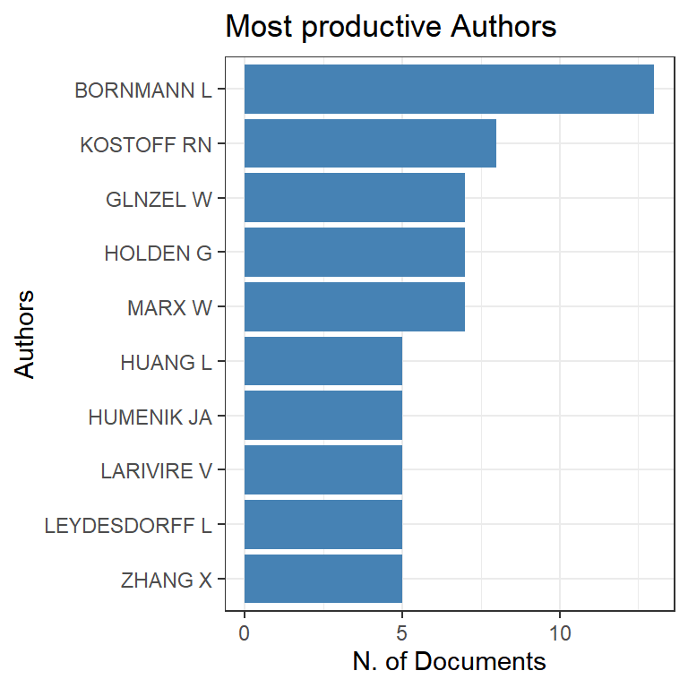

## Summary Plot-2 (Most Productive Countries)

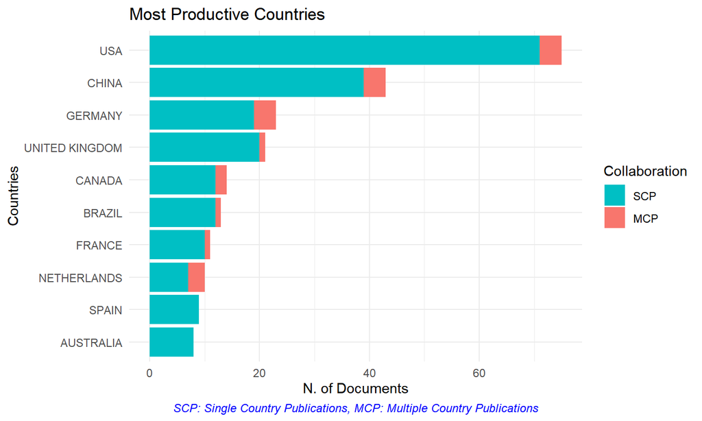

## Summary Plot-3 (Annual Scientific Production)

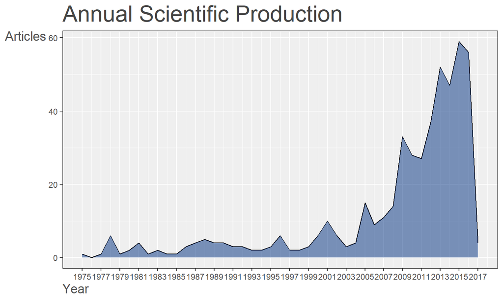

## Summary Plot-4 (Average Article Citation)

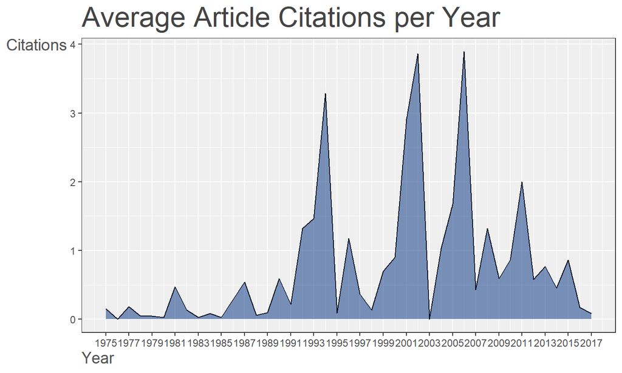

## Top Authors Over time

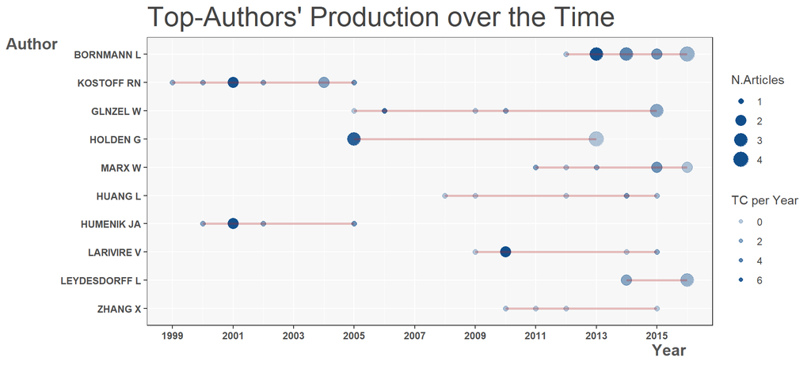

## Network Plots

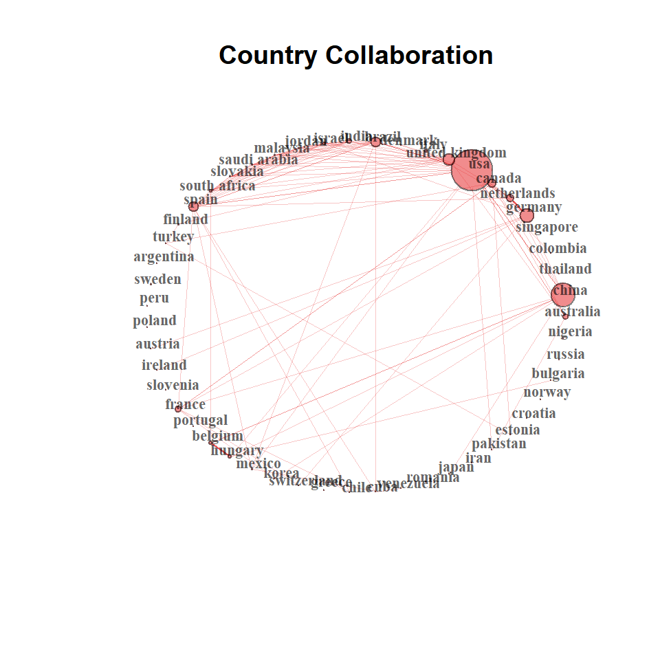

  Country Collaboration

## Co-word Analysis

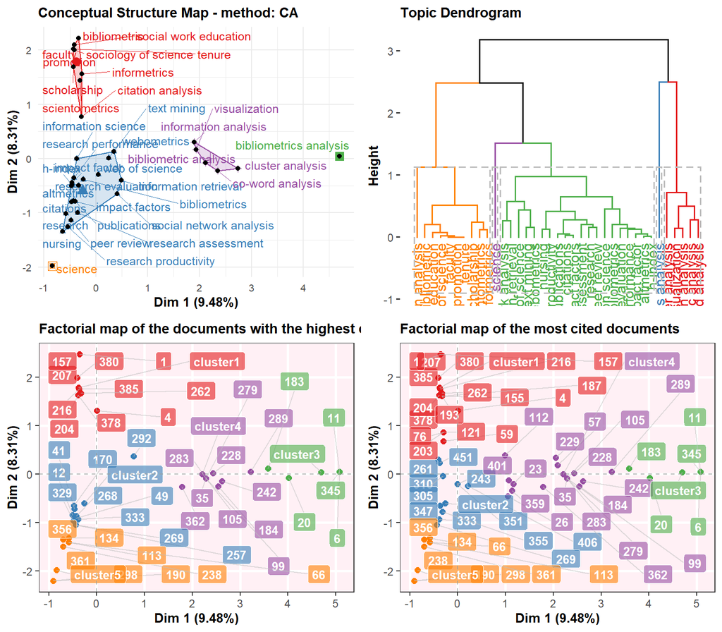

Conceptual Structure

## Author collaboration network

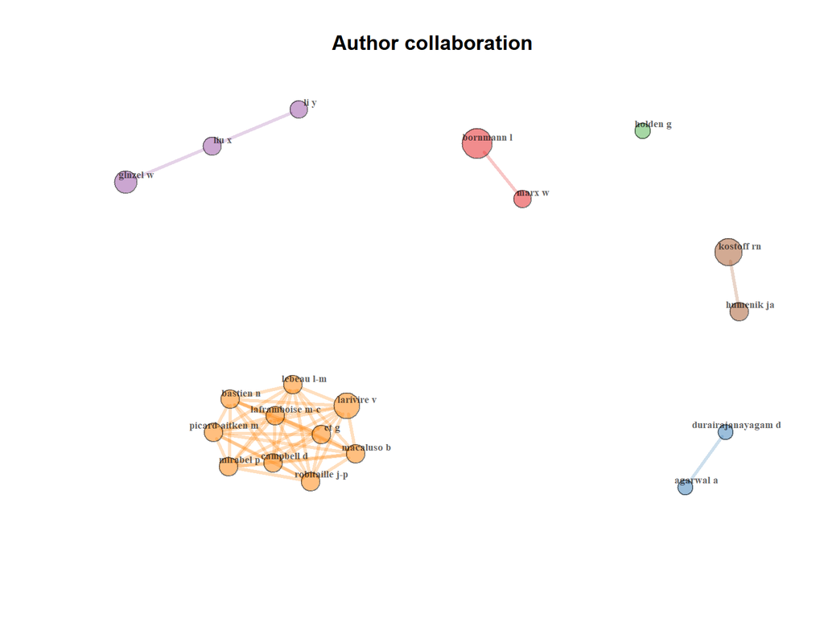

## There is a gui too!

```r
biblioshiny()
```

## References

Addor, N, and LA Melsen. 2019. “Legacy, Rather Than Adequacy, Drives the Selection of Hydrological Models.” *Water Resources Research* 55 (1): 378–90.

Aria, Massimo, and Corrado Cuccurullo. 2017. “Bibliometrix: An R-Tool for Comprehensive Science Mapping Analysis.” *Journal of Informetrics* 11 (4): 959–75. https://doi.org/10.1016/j.joi.2017.08.007.

Crisan, Anamaria, Tamara Munzner, and Jennifer L Gardy. 2018. “Adjutant: An R-Based Tool to Support Topic Discovery for Systematic and Literature Reviews.” *Bioinformatics* 35 (6): 1070–2.

Grames, Eliza M., Andrew N. Stillman, Morgan W. Tingley, and Chris S. Elphick. 2019. “An Automated Approach to Identifying Search Terms for Systematic Reviews Using Keyword Co-Occurrence Networks.” *Methods in Ecology and Evolution* 0 (ja). https://doi.org/10.1111/2041-210X.13268.

Grames, Eliza, Andrew Stillman, Morgan Tingley, and Chris Elphick. 2019. *Litsearchr: Automated Search Term Selection and Search Strategy for Systematic Reviews*.

Lajeunesse, Marc J. 2016. “Facilitating Systematic Reviews, Data Extraction and Meta-Analysis with the Metagear Package for R.” *Methods in Ecology and Evolution* 7 (3): 323–30.

Westgate, Martin J. 2018. “Revtools: Bibliographic Data Visualization for Evidence Synthesis in R.” *bioArXiv*. https://doi.org/10.1101/262881.